# Selección de variables con conjunto de datos LendingClub

Juan Gómez Romero

15 de marzo de 2022

Selección de variables con el dataset [Lending Club](https://www.lendingclub.com/info/download-data.action).

[Lending Club](https://www.lendingclub.com/) es una financiera p2p (*peer to peer*) que ofrece información anonimizada sobre sus clientes. En este ejemplo utilizaremos un conjunto de datos sobre los préstamos (*loans*) vigentes en el último trimestre de 2017. El objetivo final es construir un modelo que prediga el estado de un préstamo (`loan status`) a partir del resto de variables. Se consideran los siguientes estados:

- No pagado (‘Unpaid’)
  - ‘Late (16-30 days)’
  - ‘Late (31-120 days)’
  - ‘In Grace Period’
  - ‘Charged Off’
- Pagado (‘Paid’)
  - ‘Current’

*ATENCIÓN*: En este cuaderno vamos a trabajar con todas las instancias del dataset. Estrictamente, la selección de variables debería hacerse únicamente sobre el conjunto de datos de entrenamiento. Y, siendo más estrictos aún, sobre cada una de las particiones de la validación cruzada. Ampliar información: [Cross-validation gone wrong](https://betatim.github.io/posts/cross-validation-gone-wrong/).

# Lectura de datos

Comenzamos leyendo los datos disponibles. Podemos utilizar `n_max` para limitar la cantidad de filas con las que queremos trabajar y especificar qué valores queremos que se codifiquen como valores perdidos de R.

```r
data_raw <- read_csv('LoanStats_2017Q4.csv', na = c('NA', 'n/a', '', ' '), n_max = 10000)
head(data_raw)
```

| id | member_id | loan_amnt | funded_amnt | funded_amnt_inv | term | int_rate | installment | grade | sub_grade | emp_title | emp_length | home_ownership | annual_inc | verification_status | issue_d | loan_status | pymnt_plan | url | desc | purpose | title | zip_code | addr_state | dti | delinq_2yrs | earliest_cr_line | inq_last_6mths | mths_since_last_delinq | mths_since_last_record | … |
| --- | --- | --- | --- | --- | --- | --- | --- | --- | --- | --- | --- | --- | --- | --- | --- | --- | --- | --- | --- | --- | --- | --- | --- | --- | --- | --- | --- | --- | --- | --- |
| NA | NA | 35000 | 35000 | 35000 | 60 months | 11.99% | 778.38 | B | B5 | Project Manager | < 1 year | RENT | 65000 | Source Verified | Dec-2017 | Current | n | NA | NA | debt_consolidation | Debt consolidation | 926xx | CA | 26.81 | 0 | Oct-2005 | 0 | NA | NA | … |
| NA | NA | 6000 | 6000 | 6000 | 36 months | 7.35% | 186.23 | A | A4 | Business Development | 1 year | RENT | 65000 | Not Verified | Dec-2017 | Current | n | NA | NA | debt_consolidation | Debt consolidation | 070xx | NJ | 8.35 | 0 | Oct-1998 | 1 | 25 | NA | … |
| NA | NA | 40000 | 40000 | 40000 | 36 months | 6.08% | 1218.33 | A | A2 | Editor/Writer | < 1 year | MORTGAGE | 60000 | Source Verified | Dec-2017 | Current | n | NA | NA | debt_consolidation | Debt consolidation | 200xx | DC | 25.46 | 0 | Aug-2000 | 0 | NA | NA | … |
| NA | NA | 10000 | 10000 | 10000 | 60 months | 23.88% | 286.99 | E | E2 | EMT | 10+ years | RENT | 42000 | Source Verified | Dec-2017 | Current | n | NA | NA | credit_card | Credit card refinancing | 726xx | AR | 31.17 | 0 | Oct-1998 | 0 | NA | NA | … |
| NA | NA | 27000 | 27000 | 27000 | 60 months | 9.93% | 572.75 | B | B2 | Data Scientist | 3 years | RENT | 68000 | Not Verified | Dec-2017 | Current | n | NA | NA | debt_consolidation | Debt consolidation | 752xx | TX | 30.04 | 0 | Jul-2002 | 0 | NA | NA | … |
| NA | NA | 19000 | 19000 | 19000 | 36 months | 7.35% | 589.72 | A | A4 | Insurance Auditor | 6 years | MORTGAGE | 90000 | Source Verified | Dec-2017 | Current | n | NA | NA | debt_consolidation | Debt consolidation | 960xx | CA | 11.92 | 0 | Oct-2005 | 0 | NA | NA | … |

```r
status <- df_status(data_raw)
```

```
##                                       variable q_zeros p_zeros  q_na   p_na
## 1                                           id       0    0.00 10000 100.00
## 2                                    member_id       0    0.00 10000 100.00
## 3                                    loan_amnt       0    0.00     0   0.00
## 4                                  funded_amnt       0    0.00     0   0.00
## 5                              funded_amnt_inv       0    0.00     0   0.00
## 6                                         term       0    0.00     0   0.00
## 7                                     int_rate       0    0.00     0   0.00
## 8                                  installment       0    0.00     0   0.00
## 9                                        grade       0    0.00     0   0.00
## 10                                   sub_grade       0    0.00     0   0.00
## 11                                   emp_title       0    0.00   811   8.11
## 12                                  emp_length       0    0.00   803   8.03
## 13                              home_ownership       0    0.00     0   0.00
## 14                                  annual_inc      14    0.14     0   0.00
```

[output cut: 277 more lines]

# Eliminar columnas no útiles

A continuación vamos a eliminar las columnas que no son útiles. Consideramos columnas no útiles las siguientes:

- Columnas con más del 90% de los valores a 0
- Columnas con más del 50% de los valores a NA
- Identificar columnas con <= 3 valores diferentes
- Identificar columnas >75% valores diferentes

Obviamente, esta selección es bastante tosca. Convendría justificar estas decisiones a partir de la semántica de las columnas.

Para ello, trabajaremos con la tabla `status`, que incluye una fila por cada variable y varias columnas especificando número y proporción de 0, NA, valores únicos, etc. Tomaremos de esta tabla los nombres de variables (columna `variable`) que cumplen determinados requisitos y después crearemos una lista (variable `remove_cols`), que se utiliará para borrar columnas. El resultado se guardará en `data`. No queremos eliminar `loan_status`, así que comenzaremos por excluirla de la tabla `status` para no tenerlo en cuenta en adelante.

Excluir `loan_status` de la tabla `status`:

```r
status <- status %>%
  filter(variable != 'loan_status')
```

Identificar columnas con más del 90% de los valores a 0:

```r
zero_cols <- status %>%
  filter(p_zeros > 90) %>%
  select(variable)
```

Identificar columnas con más del 50% de los valores a NA:

```r
na_cols <- status %>%
  filter(p_na > 50) %>%
  select(variable)
```

Identificar columnas con <= 3 valores diferentes:

```r
eq_cols <- status %>%
  filter(unique <= 3) %>%
  select(variable)
```

Identificar columnas >75% valores diferentes:

```r
dif_cols <- status %>%
  filter(unique > 0.75 * nrow(data_raw)) %>%
  select(variable)
```

Eliminar columnas excluidas:

```r
remove_cols <- bind_rows(
  list(
    zero_cols,
    na_cols,
    eq_cols,
    dif_cols
  )
)

data <- data_raw %>%
  select(-one_of(remove_cols$variable))
```

```r
head(data)
```

| loan_amnt | funded_amnt | funded_amnt_inv | int_rate | installment | grade | sub_grade | emp_title | emp_length | annual_inc | loan_status | purpose | title | zip_code | addr_state | dti | delinq_2yrs | earliest_cr_line | inq_last_6mths | open_acc | pub_rec | revol_util | total_acc | out_prncp | out_prncp_inv | total_pymnt | total_pymnt_inv | total_rec_prncp | total_rec_int | last_pymnt_amnt | … |
| --- | --- | --- | --- | --- | --- | --- | --- | --- | --- | --- | --- | --- | --- | --- | --- | --- | --- | --- | --- | --- | --- | --- | --- | --- | --- | --- | --- | --- | --- | --- |
| 35000 | 35000 | 35000 | 11.99% | 778.38 | B | B5 | Project Manager | < 1 year | 65000 | Current | debt_consolidation | Debt consolidation | 926xx | CA | 26.81 | 0 | Oct-2005 | 0 | 5 | 0 | 63.7% | 16 | 34571.33 | 34571.33 | 720.10 | 720.10 | 428.67 | 291.43 | 778.38 | … |
| 6000 | 6000 | 6000 | 7.35% | 186.23 | A | A4 | Business Development | 1 year | 65000 | Current | debt_consolidation | Debt consolidation | 070xx | NJ | 8.35 | 0 | Oct-1998 | 1 | 6 | 0 | 17.7% | 23 | 5850.52 | 5850.52 | 180.11 | 180.11 | 149.48 | 30.63 | 186.23 | … |
| 40000 | 40000 | 40000 | 6.08% | 1218.33 | A | A2 | Editor/Writer | < 1 year | 60000 | Current | debt_consolidation | Debt consolidation | 200xx | DC | 25.46 | 0 | Aug-2000 | 0 | 4 | 0 | 64.7% | 6 | 38984.34 | 38984.34 | 1184.55 | 1184.55 | 1015.66 | 168.89 | 1218.33 | … |
| 10000 | 10000 | 10000 | 23.88% | 286.99 | E | E2 | EMT | 10+ years | 42000 | Current | credit_card | Credit card refinancing | 726xx | AR | 31.17 | 0 | Oct-1998 | 0 | 14 | 0 | 79.5% | 20 | 9912.01 | 9912.01 | 253.82 | 253.82 | 87.99 | 165.83 | 286.99 | … |
| 27000 | 27000 | 27000 | 9.93% | 572.75 | B | B2 | Data Scientist | 3 years | 68000 | Current | debt_consolidation | Debt consolidation | 752xx | TX | 30.04 | 0 | Jul-2002 | 0 | 14 | 0 | 35.8% | 20 | 25444.39 | 25444.39 | 1735.51 | 1735.51 | 1555.61 | 179.90 | 572.75 | … |
| 19000 | 19000 | 19000 | 7.35% | 589.72 | A | A4 | Insurance Auditor | 6 years | 90000 | Current | debt_consolidation | Debt consolidation | 960xx | CA | 11.92 | 0 | Oct-2005 | 0 | 9 | 0 | 37.4% | 29 | 18526.66 | 18526.66 | 570.32 | 570.32 | 473.34 | 96.98 | 589.72 | … |

```r
df_status(data)
```

```
##                 variable q_zeros p_zeros q_na  p_na q_inf p_inf      type
## 1              loan_amnt       0    0.00    0  0.00     0     0   numeric
## 2            funded_amnt       0    0.00    0  0.00     0     0   numeric
## 3        funded_amnt_inv       0    0.00    0  0.00     0     0   numeric
## 4               int_rate       0    0.00    0  0.00     0     0 character
## 5            installment       0    0.00    0  0.00     0     0   numeric
## 6                  grade       0    0.00    0  0.00     0     0 character
## 7              sub_grade       0    0.00    0  0.00     0     0 character
## 8              emp_title       0    0.00  811  8.11     0     0 character
## 9             emp_length       0    0.00  803  8.03     0     0 character
## 10            annual_inc      14    0.14    0  0.00     0     0   numeric
## 11           loan_status       0    0.00    0  0.00     0     0 character
## 12               purpose       0    0.00    0  0.00     0     0 character
## 13                 title       0    0.00    0  0.00     0     0 character
## 14              zip_code       0    0.00    0  0.00     0     0 character
```

[output cut: 127 more lines]

# Eliminar filas no útiles

```r
data <- data %>%
  filter(loan_status
         %in%
           c('Late (16-30 days)',
             'Late (31-120 days)',
             'In Grace Period',
             'Charged Off',
             'Current'))
```

# Recodificar valores de clase objetivo

Vamos a convertir el problema en una clasificación binaria recodificando los valores de `loan_status` a dos categorías: *Paid*, *Unpaid*. La clase mayoritaria es *Paid* y consideraremos “clase positiva” a *Unpaid* (los casos interesantes de detectar son aquellos en que no se paga el préstamo).

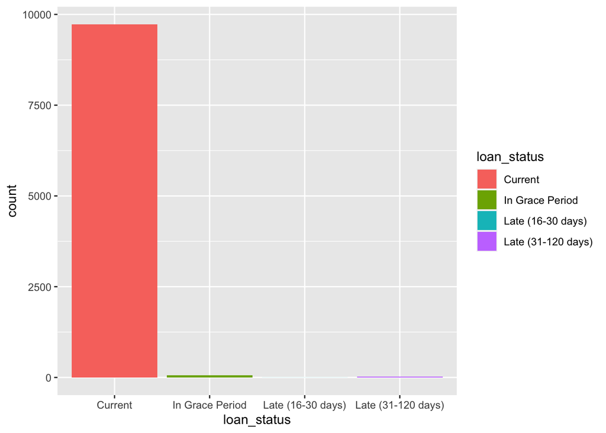

```r
ggplot(data) +
  geom_histogram(aes(x = loan_status, fill = loan_status), stat = 'count')
```

```r
data <- data %>%
  mutate(loan_status = case_when(
    loan_status == 'Late (16-30 days)'  ~ 'Unpaid',
    loan_status == 'Late (31-120 days)' ~ 'Unpaid',
    loan_status == 'In Grace Period'    ~ 'Unpaid',
    loan_status == 'Charged Off'        ~ 'Unpaid',
    loan_status == 'Current'            ~ 'Paid'))
```

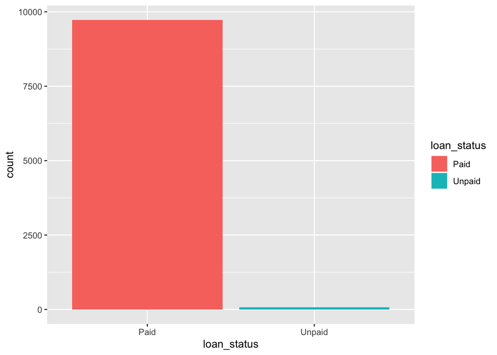

```r
ggplot(data) +
  geom_histogram(aes(x = loan_status, fill = loan_status), stat = 'count')
```

# Identificar columnas según correlación

Vamos a continuar seleccionando columnas. Comenzaremos seleccionando las columnas que tienen una alta correlación con la variable objetivo `loan_status` y, por tanto, son interesantes (son buenos predictores de su comportamiento). Continuaremos estudiante las columnas que tienen una alta correlación entre sí y, por tanto, solo nos interesa una de ellas (todas aportan la misma información).

## Alta correlación con la variable objetivo

Construimos una tabla de correlación de las variables con respecto a `loan_status`. Por defecto nos dará error, ya que es necesario imputar valores perdidos y convertir las cadenas a valores de categorías codificadas con números.

```r
# correlation_table(data, target='loan_status')
```

Para ello, eliminamos las filas con `NAs` usando `na.exclude()` y convertimos las cadenas a *factor* + los *factor* a números:

```r
data_num <- data %>%
  na.exclude() %>%
  mutate_if(is.character, as.factor) %>%
  mutate_if(is.factor, as.numeric)
```

Ahora sí podemos calcular la correlación:

```r
cor_target <- correlation_table(data_num, target='loan_status')
```

Y quedarnos solo con las variables que tienen una correlación por encima del 0.01 (en valor absoluto):

```r
important_vars <- cor_target %>%
  filter(abs(loan_status) >= 0.01)

data <- data %>%
  select(one_of(important_vars$Variable))
```

## Alta correlación entre sí

Construirmos una tabla de correlación con todas las variables utilizando `rcorr` (también se podría utilizar `correlation_table` de [funModeling](https://www.rdocumentation.org/packages/funModeling/versions/1.9.4/topics/correlation_table)). Al igual que en el caso anterior, es necesario eliminar filas con valores `NA` y convertir las cadenas a valores numéricos.

```r
data_num <- data %>%
  na.exclude() %>%
  mutate_if(is.character, as.factor) %>%
  mutate_if(is.factor, as.numeric)

rcorr_result <- rcorr(as.matrix(data_num))
```

Para visualizar la matriz de correlación, utilizamos `corrplot` (previa transformación a `tibble`):

```r
cor_matrix <- as.tibble(rcorr_result$r, rownames = "variable")
```

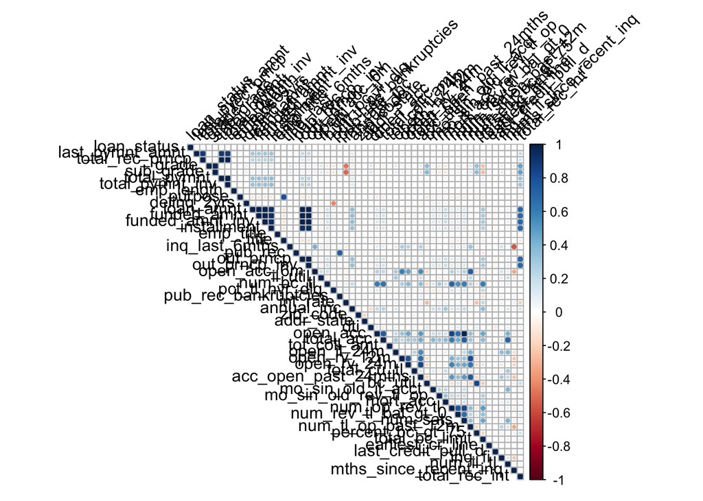

```r
corrplot(rcorr_result$r, type = "upper", order = "original", tl.col = "black", tl.srt = 45)
```

Se puede observar que hay varias variables con alto índice de correlación entre sí; en concreto: ‘open_rv_24m’, ‘acc_open_past_24mths’, ‘open_il_24m’, ‘total_rec_prncp’, ‘total_pymnt’, ‘total_pymnt_inv’, ‘grade’.

Vamos a agrupar las variables según el valor de correlación entre ellas ([coeficiente de Pearson](https://es.wikipedia.org/wiki/Coeficiente_de_correlaci%C3%B3n_de_Pearson)). Utilizaremos `varclus`, que crea un cluster jearárquico a partir de la similitud entre variables calculada a partir de la medida especificada:

```r
v <- varclus(as.matrix(data_num), similarity="pearson")
```

Podemos visualizar el cluster creado:

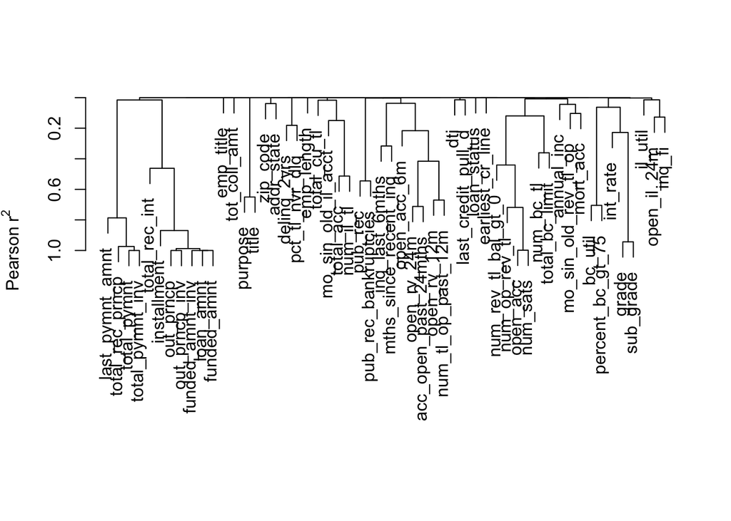

```r
plot(v)
```

Para quedarnos con las variables representativas, cortaremos el árbol de agrupaciones a una determinada altura para obtener los clusteres a esa altura. Esto se puede hacer especificando un valor de la medida de similitud (*Pearson*) o indicando el número de clusteres que queremos (dejando que la función interprete cómo debe realizar el corte). Utilizando la segunda opción podemos obtener 25 grupos:

```r
groups <- cutree(v$hclust, 25)
```

Finalmente, nos quedamos con una variable representativa de cada grupo, que será la que seleccionemos para el análisis. Para ello, convertimos los grupos en `data.frame`, hacemos un `group_by` por número de cluster asignado y seleccionamos una instancia con `sample_n`:

```r
not_correlated_vars <- enframe(groups) %>%
  group_by(value) %>%
  sample_n(1)
```

Y retenemos en `data` las variables elegidas:

```r
data <- data %>%
  select(one_of(not_correlated_vars$name))
```

# Guardar fichero

```r
head(data)
```

| loan_status | total_pymnt_inv | int_rate | emp_length | title | delinq_2yrs | total_rec_int | emp_title | mths_since_recent_inq | pub_rec_bankruptcies | open_rv_24m | il_util | num_bc_tl | annual_inc | zip_code | addr_state | dti | mo_sin_old_il_acct | tot_coll_amt | open_il_24m | total_cu_tl | bc_util | mo_sin_old_rev_tl_op | earliest_cr_line | last_credit_pull_d |
| --- | --- | --- | --- | --- | --- | --- | --- | --- | --- | --- | --- | --- | --- | --- | --- | --- | --- | --- | --- | --- | --- | --- | --- | --- |
| Paid | 720.10 | 11.99% | < 1 year | Debt consolidation | 0 | 291.43 | Project Manager | NA | 0 | 0 | 73 | 2 | 65000 | 926xx | CA | 26.81 | 142 | 0 | 2 | 5 | 63.7 | 146 | Oct-2005 | Feb-2018 |
| Paid | 180.11 | 7.35% | 1 year | Debt consolidation | 0 | 30.63 | Business Development | 4 | 0 | 2 | 10 | 5 | 65000 | 070xx | NJ | 8.35 | 230 | 0 | 0 | 0 | 40.6 | 199 | Oct-1998 | Feb-2018 |
| Paid | 1184.55 | 6.08% | < 1 year | Debt consolidation | 0 | 168.89 | Editor/Writer | NA | 0 | 0 | 77 | 2 | 60000 | 200xx | DC | 25.46 | 68 | 0 | 1 | 1 | 64.7 | 208 | Aug-2000 | Dec-2017 |
| Paid | 253.82 | 23.88% | 10+ years | Credit card refinancing | 0 | 165.83 | EMT | NA | 0 | 2 | NA | 11 | 42000 | 726xx | AR | 31.17 | 61 | 0 | 0 | 0 | 96.1 | 230 | Oct-1998 | Feb-2018 |
| Paid | 1735.51 | 9.93% | 3 years | Debt consolidation | 0 | 179.90 | Data Scientist | 8 | 0 | 0 | 41 | 7 | 68000 | 752xx | TX | 30.04 | 149 | 0 | 1 | 0 | 39.2 | 185 | Jul-2002 | Feb-2018 |
| Paid | 570.32 | 7.35% | 6 years | Debt consolidation | 0 | 96.98 | Insurance Auditor | 3 | 0 | 0 | NA | 10 | 90000 | 960xx | CA | 11.92 | 64 | 0 | 4 | 1 | 46.6 | 146 | Oct-2005 | Feb-2018 |

```r
df_status(data)
```

```
##                 variable q_zeros p_zeros q_na  p_na q_inf p_inf      type
## 1            loan_status       0    0.00    0  0.00     0     0 character
## 2        total_pymnt_inv      18    0.18    0  0.00     0     0   numeric
## 3               int_rate       0    0.00    0  0.00     0     0 character
## 4             emp_length       0    0.00  794  8.10     0     0 character
## 5                  title       0    0.00    0  0.00     0     0 character
## 6            delinq_2yrs    8333   84.96    0  0.00     0     0   numeric
## 7          total_rec_int      21    0.21    0  0.00     0     0   numeric
## 8              emp_title       0    0.00  802  8.18     0     0 character
## 9  mths_since_recent_inq     851    8.68 1216 12.40     0     0   numeric
## 10  pub_rec_bankruptcies    8574   87.42    0  0.00     0     0   numeric
## 11           open_rv_24m    1742   17.76    0  0.00     0     0   numeric
## 12               il_util      42    0.43 1596 16.27     0     0   numeric
## 13             num_bc_tl      42    0.43    0  0.00     0     0   numeric
## 14            annual_inc      13    0.13    0  0.00     0     0   numeric
```

[output cut: 37 more lines]

```r
write_csv(data, 'LoanStats_2017Q4-SelVar.csv')
```

El fichero final ya sí puede utilizarse para construir un modelo de predicción utilizando [`caret`](http://topepo.github.io/caret/).